# Advanced Topic Instructions

Nick Kolarik

3/5/2020

## Introduce your problem

Uncertainty surrounding water availability in the West has implications tied to agriculture, fisheries, and overall ecosystem health. Understanding of spatiotemporal trajectories of open surface water bodies lends insight to both intra- and interannual risks associated with water availability.Topogaphy is a first-order control on hydrological conditions and understanding contributions to surface water bodies as dictated by topographical features is useful for detection of surface water and wetlands (Hird et al. 2017). Here, I explore some ways for obtaining topographical indices (topographic position index (TPI) and topographic wetness index (TWI)) and other values derived from a DEM to be utilized alongside remotely sensed datasets in classification and model parameterization for prediction of water availability under future conditions.

## PSUEDOCODE!!

```r
#install.packages('sf')
#install.packages('dynatopmodel')
#install.packages('landsat')
#install.packages('microbenchmark')
#install.packages('tidyverse')
#install.packages('spatialEco')
library(raster)
library(sf)
library(dynatopmodel)
library(landsat)
library(microbenchmark)
library(tidyverse)
library(spatialEco)
library(googledrive) ## for storing files
```

```r
##PSEUDOCODE!

#setwd()

## defining projection of interest e

## Teton/Fremont/Madison Counties as example study area
## HUC10 units

## project it

## Dissolve polys into one larger poly

## DEM - load it, project it

## terrain values of interest -> slope, aspect, TPI; using queen's case (neighbors = 8)

##Topographic wetness index

## slope (radians)
## tangent of slope
## contributing flow
##TWI calculation

## cropping all terrain variables for study area

## plot TWI, TPW, Slope, Aspect
```

## Introduce the packages

Critical steps for this process are loading the the DEM, performing analyses to derive variables such as slope, aspect, TPI, and TWI. The terrain() function in the raster package is the most straightforward way to calculate slope, aspect, and TPI from a DEM. Topmodel (dynatopmodel) is a way that I have seen others calculate TWI other than using ArcGIS. These were the baselines used for benchmarking other methods. Plotting these help to make sure outputs are sensible.

I found an alternative function for creating slope and aspect rasters from a DEM stored as a SpatialGridDataFrame in the landsat package for comparison with the terrain() function from the raster package. Similarly, I compared the tpi() function in the spatialEco package (takes a DEM as a raster as the only required argument) to the TPI value returned from the terrain() function.

Through exploration, I found that the dynatopmodel package is not well maintained and has bugs that I was unable to resolve quickly. Fortunately, others have already been in this position and I found some function definitions on stack overflow to work-around the dynatopmodel issue.

```r
## update with your local dir -> setwd to location where downloaded files should go -> didn't futz with ./data/file.ext format in the lapply below
#setwd('C:/Users/nicholaskolarik/DDeSuP/mgmt/')
wd <- 'C:/Users/nicho/BSU/rgeo/topo'
setwd(wd)

## google drive dir
folder.url <- "https://drive.google.com/open?id=1iwjO_HNMNYUaIxdfYPnz-NUMpcQBKQbu"
folder <- drive_get(as_id(folder.url))
```

```
## Using an auto-discovered, cached token.
## To suppress this message, modify your code or options to clearly consent to the use of a cached token.
## See gargle's "Non-interactive auth" vignette for more details:
## https://gargle.r-lib.org/articles/non-interactive-auth.html
## The googledrive package is using a cached token for nicholaskolarik@u.boisestate.edu.
```

```r
## list files in drive dir
files <- drive_ls(folder)

## download them locally
## update your local path!
#path <- "/path/to/your/local/directory/not/class repo/"
#path <- "./data/googletest/"
lapply(files$id, function(x) drive_download(as_id(x), overwrite = TRUE)) #replace the path with a folder on your computer outside of the repo directory
```

```
## File downloaded:
##   * flow_acc.tif
## Saved locally as:
##   * flow_acc.tif
```

```
## File downloaded:
##   * te_fre_mad_huc10.sbx
## Saved locally as:
##   * te_fre_mad_huc10.sbx
```

```
## File downloaded:
##   * te_fre_mad_huc10.cpg
## Saved locally as:
##   * te_fre_mad_huc10.cpg
```

```
## File downloaded:
##   * te_fre_mad_huc10.shp.xml
## Saved locally as:
##   * te_fre_mad_huc10.shp.xml
```

```
## File downloaded:
##   * te_fre_mad_huc10.dbf
## Saved locally as:
##   * te_fre_mad_huc10.dbf
```

```
## File downloaded:
##   * te_fre_mad_huc10.shx
## Saved locally as:
##   * te_fre_mad_huc10.shx
```

```
## File downloaded:
##   * te_fre_mad_huc10.shp
## Saved locally as:
##   * te_fre_mad_huc10.shp
```

```
## File downloaded:
##   * te_fre_mad_huc10.sbn
## Saved locally as:
##   * te_fre_mad_huc10.sbn
```

```
## File downloaded:
##   * te_fre_mad_huc10.prj
## Saved locally as:
##   * te_fre_mad_huc10.prj
```

```
## File downloaded:
##   * DEM_ID_prj.tif
## Saved locally as:
##   * DEM_ID_prj.tif
```

[output not shown]

```r
setwd(wd)
## defining projection of interest -> 'borrowed' from in class example
idaho.cent <- "+proj=tmerc +lat_1=41.66666666666666 +lon_0=-114 +k=0.9999473679999999 +x_0=500000.0001016001 +y_0=0 +ellps=GRS80 +datum=NAD83 +to_meter=0.3048006096012192 +no_defs "

## Teton/Fremont/Madison Counties as example study area
## HUC10 units
#tefremad <- read_sf("./data/te_fre_mad_huc10.shp")
tefremad <- read_sf("./te_fre_mad_huc10.shp")

## project it
tefremad.prj <- st_transform(tefremad, st_crs(idaho.cent))

## tidyverse version of ESRI 'dissovle' -> summarise
## defining area as the only attribute of interest
study.area <- tefremad.prj %>% summarise(area = sum(AreaSqKm))

## DEM
#dem <- raster('./data/DEM_ID_prj.tif')
dem <- raster('./DEM_ID_prj.tif')
dem.prj <- projectRaster(dem, crs = idaho.cent)
dem.tfm <- crop(dem.prj, study.area)

## terrain values of interest -> slope, aspect, TPI; using queen's case (neighbors = 8)
terr.vals <- terrain(dem.tfm, opt = c('slope', 'aspect', 'TPI'), neighbors = 8)

## SpatialGridDataFrame
#sgdf <- as(dem.tfm, "SpatialGridDataFrame")
#slopeasp.time <- microbenchmark(slopeasp(sgdf)) ## TAKES FOREVER!!! OVER 20 minutes!


##Topographic wetness index
#topmodel.lyrs <- build_layers(dem.tfm)

## https://stackoverflow.com/questions/58553966/calculating-twi-in-r
## Because dynatopmodel was returning an error: Error in upslope.area(dem, atb = TRUE, fill.sinks = fill.sinks, deg = deg) :
## Raster has differing x and y cell resolutions. Check that it is in a projected coordinate system (e.g. UTM) and
## use raster::projectRaster to reproject to one if not. Otherwise consider using raster::resample

upslope <- function (dem, log = TRUE, atb = FALSE, deg = 0.12, fill.sinks = TRUE)
{
  if (!all.equal(xres(dem), yres(dem))) {
    stop("Raster has differing x and y cell resolutions. Check that it is in a projected coordinate system (e.g. UTM) and use raster::projectRaster to reproject to one if not. Otherwise consider using raster::resample")
  }
  if (fill.sinks) {
    capture.output(dem <- invisible(raster::setValues(dem, topmodel::sinkfill(raster::as.matrix(dem), res = xres(dem), degree = deg))))
  }
  topidx <- topmodel::topidx(raster::as.matrix(dem), res = xres(dem))
  a <- raster::setValues(dem, topidx$area)
  if (log) {
    a <- log(a)
  }
  if (atb) {
    atb <- raster::setValues(dem, topidx$atb)
    a <- addLayer(a, atb)
    names(a) <- c("a", "atb")
  }
  return(a)
}

create_layers <- function (dem, fill.sinks = TRUE, deg = 0.1)
{
  layers <- stack(dem)
  message("Building upslope areas...")
  a.atb <- upslope(dem, atb = TRUE, fill.sinks = fill.sinks, deg = deg)
  layers <- addLayer(layers, a.atb)
  names(layers) <- c("filled.elevations", "upslope.area", "twi")
  return(layers)
}

#dem.lyrs <- create_layers(dem.tfm)## TAKES FOREVER!

## calculating TWI in radians
#twi.man <- log(dem.lyrs$upslope.area/tan(slope/180))

## TWI - built flow accumulation in ArcMap due to inefficiencies in R
flow.acc <- raster('./data/flow_acc.tif')
flow.acc.prj <- crop(projectRaster(flow.acc, crs = idaho.cent), study.area)

## slope (radians)
slope <- terr.vals$slope
## tangent of slope (in radians)
tan.slope <- tan(slope)
## contributing flow
flow.contr <- flow.acc.prj + 1 * res(dem.tfm)[1]
##TWI calculation!adding 0.000001 to denominator to account for slopes of 0
twi <- log(flow.contr/(tan.slope + 0.000001))
```

## Evaluate your choice

```r
##BENCHMARKING

## benchmarking the two options terrain() and slopeasp() from raster and landsat packages respectively
terr.vals.time <- microbenchmark(terrain(dem.tfm, opt = c('slope', 'aspect'), neighbors = 8)) ## mean = 3376790825

## benchmarking TPI options terrain() and tpi() from raster and spatialEco packages respectively
tpi.terr.time <- microbenchmark(terrain(dem.tfm, opt = 'tpi', neighbors = 8)) ## mean = 472538306
tpi.spEco.time <- microbenchmark(tpi(dem.tfm)) ## mean = 1014031592
```

## Show us your final product

Did you make a map? Let’s see it.

### TWI plot

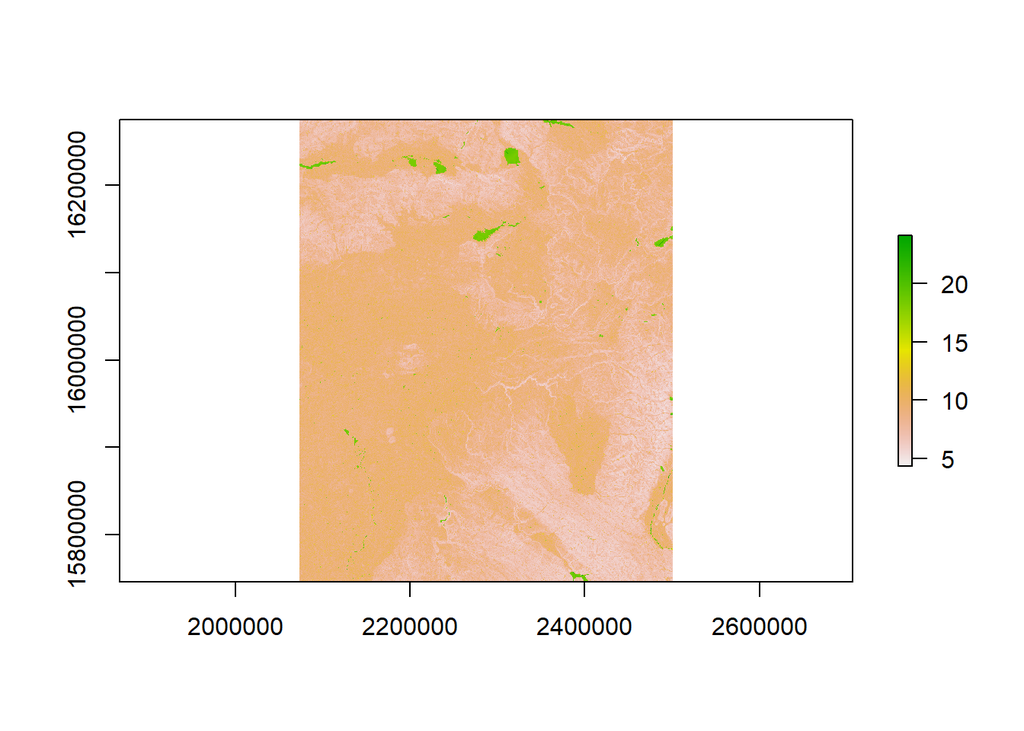

```r
plot(twi)
```

### TPI plot

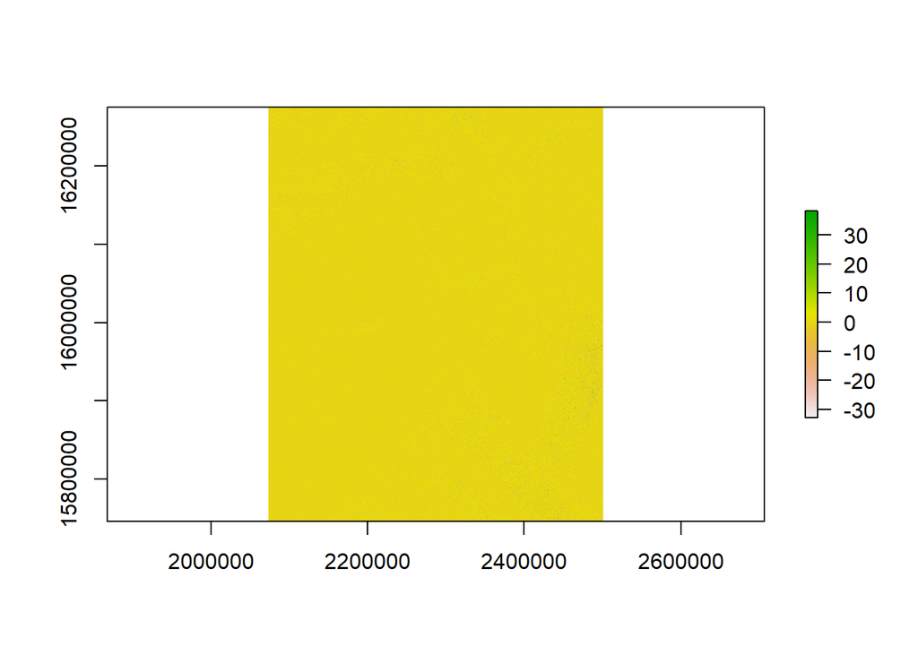

```r
plot(terr.vals$tpi)
```

### Slope plot

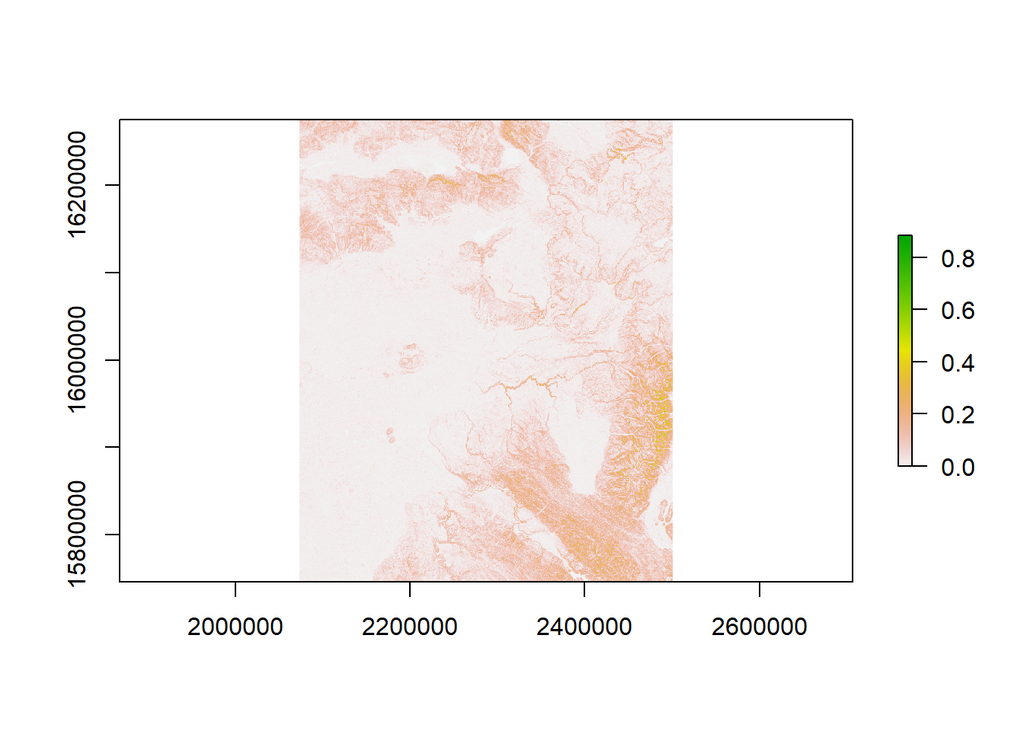

```r
plot(terr.vals$slope)
```

### Aspect plot

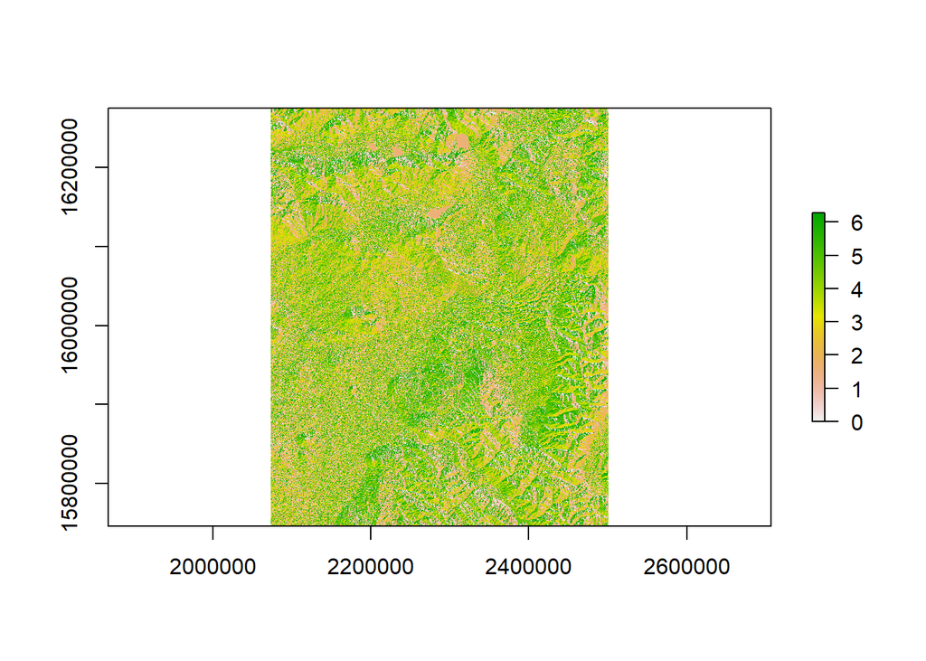

```r
plot(terr.vals$aspect)
```

## Reflect

Do not stray from the terrain() function in the raster package for calculation of slope, aspect, and TPI. This method is tried and true and I expect will continue to be maintained and documented as well or better than any other option. As for TWI, R is slow for its calculation due to the way the data are handled. While we *could* make this layer using R, I would encourage anyone with an ESRI license to use it for this calculation and bring the flow accumulation layer (aka upslope area) into R for further manipulation.